# Risk Factor Analysis

## Outcome Variable

**Outcome Variable:** whz

## Predictor Variables

**Intervention Variable:** earlybf

**Adjustment Set:**

- arm
- sex
- W_mage
- meducyrs
- feducyrs
- hhwealth_quart
- hfoodsec
- W_mhtcm
- vagbrth
- W_birthwt
- W_birthlen
- W_nrooms
- W_nchldlt5
- brthmon
- W_parity
- impfloor
- impsan
- safeh20
- delta_W_mage
- delta_meducyrs
- delta_feducyrs
- delta_hhwealth_quart
- delta_hfoodsec
- delta_W_mhtcm
- delta_vagbrth
- delta_W_birthwt
- delta_W_birthlen
- delta_W_nrooms
- delta_W_nchldlt5
- delta_brthmon
- delta_W_parity
- delta_impfloor
- delta_impsan
- delta_safeh20

## Stratifying Variables

The analysis was stratified on these variable(s):

- agecat
- studyid
- country

## Data Summary

| agecat | studyid | country | earlybf | n_cell | n |
| --- | --- | --- | --- | --- | --- |
| Birth | ki0047075b-MAL-ED | BANGLADESH | 1 | 152 | 240 |
| Birth | ki0047075b-MAL-ED | BANGLADESH | 0 | 88 | 240 |
| Birth | ki0047075b-MAL-ED | BRAZIL | 1 | 79 | 183 |
| Birth | ki0047075b-MAL-ED | BRAZIL | 0 | 104 | 183 |
| Birth | ki0047075b-MAL-ED | INDIA | 1 | 123 | 202 |
| Birth | ki0047075b-MAL-ED | INDIA | 0 | 79 | 202 |
| Birth | ki0047075b-MAL-ED | NEPAL | 1 | 77 | 168 |
| Birth | ki0047075b-MAL-ED | NEPAL | 0 | 91 | 168 |
| Birth | ki0047075b-MAL-ED | PERU | 1 | 211 | 279 |
| Birth | ki0047075b-MAL-ED | PERU | 0 | 68 | 279 |
| Birth | ki0047075b-MAL-ED | SOUTH AFRICA | 1 | 154 | 245 |
| Birth | ki0047075b-MAL-ED | SOUTH AFRICA | 0 | 91 | 245 |
| Birth | ki0047075b-MAL-ED | TANZANIA, UNITED REPUBLIC OF | 1 | 108 | 118 |
| Birth | ki0047075b-MAL-ED | TANZANIA, UNITED REPUBLIC OF | 0 | 10 | 118 |
| Birth | ki1000109-EE | PAKISTAN | 1 | 1 | 1 |
| Birth | ki1000109-EE | PAKISTAN | 0 | 0 | 1 |
| Birth | ki1000304b-SAS-CompFeed | INDIA | 1 | 13 | 158 |
| Birth | ki1000304b-SAS-CompFeed | INDIA | 0 | 145 | 158 |
| Birth | ki1017093c-NIH-Crypto | BANGLADESH | 1 | 19 | 23 |
| Birth | ki1017093c-NIH-Crypto | BANGLADESH | 0 | 4 | 23 |
| Birth | ki1126311-ZVITAMBO | ZIMBABWE | 1 | 6141 | 11513 |
| Birth | ki1126311-ZVITAMBO | ZIMBABWE | 0 | 5372 | 11513 |
| Birth | kiGH5241-JiVitA-3 | BANGLADESH | 1 | 93 | 15648 |
| Birth | kiGH5241-JiVitA-3 | BANGLADESH | 0 | 15555 | 15648 |
| Birth | kiGH5241-JiVitA-4 | BANGLADESH | 1 | 475 | 683 |
| Birth | kiGH5241-JiVitA-4 | BANGLADESH | 0 | 208 | 683 |
| 6 months | ki0047075b-MAL-ED | BANGLADESH | 1 | 147 | 240 |
| 6 months | ki0047075b-MAL-ED | BANGLADESH | 0 | 93 | 240 |
| 6 months | ki0047075b-MAL-ED | BRAZIL | 1 | 95 | 209 |
| 6 months | ki0047075b-MAL-ED | BRAZIL | 0 | 114 | 209 |
| 6 months | ki0047075b-MAL-ED | INDIA | 1 | 140 | 236 |
| 6 months | ki0047075b-MAL-ED | INDIA | 0 | 96 | 236 |
| 6 months | ki0047075b-MAL-ED | NEPAL | 1 | 96 | 236 |
| 6 months | ki0047075b-MAL-ED | NEPAL | 0 | 140 | 236 |
| 6 months | ki0047075b-MAL-ED | PERU | 1 | 202 | 273 |
| 6 months | ki0047075b-MAL-ED | PERU | 0 | 71 | 273 |
| 6 months | ki0047075b-MAL-ED | SOUTH AFRICA | 1 | 156 | 250 |
| 6 months | ki0047075b-MAL-ED | SOUTH AFRICA | 0 | 94 | 250 |
| 6 months | ki0047075b-MAL-ED | TANZANIA, UNITED REPUBLIC OF | 1 | 205 | 247 |
| 6 months | ki0047075b-MAL-ED | TANZANIA, UNITED REPUBLIC OF | 0 | 42 | 247 |
| 6 months | ki1000109-EE | PAKISTAN | 1 | 69 | 376 |
| 6 months | ki1000109-EE | PAKISTAN | 0 | 307 | 376 |
| 6 months | ki1000304b-SAS-CompFeed | INDIA | 1 | 97 | 1334 |
| 6 months | ki1000304b-SAS-CompFeed | INDIA | 0 | 1237 | 1334 |
| 6 months | ki1017093c-NIH-Crypto | BANGLADESH | 1 | 619 | 715 |
| 6 months | ki1017093c-NIH-Crypto | BANGLADESH | 0 | 96 | 715 |
| 6 months | ki1113344-GMS-Nepal | NEPAL | 1 | 151 | 510 |
| 6 months | ki1113344-GMS-Nepal | NEPAL | 0 | 359 | 510 |
| 6 months | ki1126311-ZVITAMBO | ZIMBABWE | 1 | 3951 | 7339 |
| 6 months | ki1126311-ZVITAMBO | ZIMBABWE | 0 | 3388 | 7339 |
| 6 months | kiGH5241-JiVitA-3 | BANGLADESH | 1 | 36 | 16784 |
| 6 months | kiGH5241-JiVitA-3 | BANGLADESH | 0 | 16748 | 16784 |
| 6 months | kiGH5241-JiVitA-4 | BANGLADESH | 1 | 3095 | 4833 |
| 6 months | kiGH5241-JiVitA-4 | BANGLADESH | 0 | 1738 | 4833 |
| 24 months | ki0047075b-MAL-ED | BANGLADESH | 1 | 128 | 211 |
| 24 months | ki0047075b-MAL-ED | BANGLADESH | 0 | 83 | 211 |
| 24 months | ki0047075b-MAL-ED | BRAZIL | 1 | 80 | 169 |
| 24 months | ki0047075b-MAL-ED | BRAZIL | 0 | 89 | 169 |
| 24 months | ki0047075b-MAL-ED | INDIA | 1 | 134 | 227 |
| 24 months | ki0047075b-MAL-ED | INDIA | 0 | 93 | 227 |
| 24 months | ki0047075b-MAL-ED | NEPAL | 1 | 95 | 228 |
| 24 months | ki0047075b-MAL-ED | NEPAL | 0 | 133 | 228 |
| 24 months | ki0047075b-MAL-ED | PERU | 1 | 149 | 201 |
| 24 months | ki0047075b-MAL-ED | PERU | 0 | 52 | 201 |
| 24 months | ki0047075b-MAL-ED | SOUTH AFRICA | 1 | 144 | 235 |
| 24 months | ki0047075b-MAL-ED | SOUTH AFRICA | 0 | 91 | 235 |
| 24 months | ki0047075b-MAL-ED | TANZANIA, UNITED REPUBLIC OF | 1 | 180 | 214 |
| 24 months | ki0047075b-MAL-ED | TANZANIA, UNITED REPUBLIC OF | 0 | 34 | 214 |
| 24 months | ki1017093c-NIH-Crypto | BANGLADESH | 1 | 443 | 514 |
| 24 months | ki1017093c-NIH-Crypto | BANGLADESH | 0 | 71 | 514 |
| 24 months | ki1113344-GMS-Nepal | NEPAL | 1 | 136 | 454 |
| 24 months | ki1113344-GMS-Nepal | NEPAL | 0 | 318 | 454 |
| 24 months | ki1126311-ZVITAMBO | ZIMBABWE | 1 | 198 | 370 |
| 24 months | ki1126311-ZVITAMBO | ZIMBABWE | 0 | 172 | 370 |
| 24 months | kiGH5241-JiVitA-3 | BANGLADESH | 1 | 1 | 8603 |
| 24 months | kiGH5241-JiVitA-3 | BANGLADESH | 0 | 8602 | 8603 |
| 24 months | kiGH5241-JiVitA-4 | BANGLADESH | 1 | 3031 | 4735 |
| 24 months | kiGH5241-JiVitA-4 | BANGLADESH | 0 | 1704 | 4735 |

The following strata were considered:

- agecat: 24 months, studyid: ki0047075b-MAL-ED, country: BANGLADESH
- agecat: 24 months, studyid: ki0047075b-MAL-ED, country: BRAZIL
- agecat: 24 months, studyid: ki0047075b-MAL-ED, country: INDIA
- agecat: 24 months, studyid: ki0047075b-MAL-ED, country: NEPAL
- agecat: 24 months, studyid: ki0047075b-MAL-ED, country: PERU
- agecat: 24 months, studyid: ki0047075b-MAL-ED, country: SOUTH AFRICA
- agecat: 24 months, studyid: ki0047075b-MAL-ED, country: TANZANIA, UNITED REPUBLIC OF
- agecat: 24 months, studyid: ki1017093c-NIH-Crypto, country: BANGLADESH
- agecat: 24 months, studyid: ki1113344-GMS-Nepal, country: NEPAL
- agecat: 24 months, studyid: ki1126311-ZVITAMBO, country: ZIMBABWE
- agecat: 24 months, studyid: kiGH5241-JiVitA-3, country: BANGLADESH
- agecat: 24 months, studyid: kiGH5241-JiVitA-4, country: BANGLADESH
- agecat: 6 months, studyid: ki0047075b-MAL-ED, country: BANGLADESH
- agecat: 6 months, studyid: ki0047075b-MAL-ED, country: BRAZIL
- agecat: 6 months, studyid: ki0047075b-MAL-ED, country: INDIA
- agecat: 6 months, studyid: ki0047075b-MAL-ED, country: NEPAL
- agecat: 6 months, studyid: ki0047075b-MAL-ED, country: PERU
- agecat: 6 months, studyid: ki0047075b-MAL-ED, country: SOUTH AFRICA
- agecat: 6 months, studyid: ki0047075b-MAL-ED, country: TANZANIA, UNITED REPUBLIC OF
- agecat: 6 months, studyid: ki1000109-EE, country: PAKISTAN
- agecat: 6 months, studyid: ki1000304b-SAS-CompFeed, country: INDIA
- agecat: 6 months, studyid: ki1017093c-NIH-Crypto, country: BANGLADESH
- agecat: 6 months, studyid: ki1113344-GMS-Nepal, country: NEPAL
- agecat: 6 months, studyid: ki1126311-ZVITAMBO, country: ZIMBABWE
- agecat: 6 months, studyid: kiGH5241-JiVitA-3, country: BANGLADESH
- agecat: 6 months, studyid: kiGH5241-JiVitA-4, country: BANGLADESH
- agecat: Birth, studyid: ki0047075b-MAL-ED, country: BANGLADESH
- agecat: Birth, studyid: ki0047075b-MAL-ED, country: BRAZIL
- agecat: Birth, studyid: ki0047075b-MAL-ED, country: INDIA
- agecat: Birth, studyid: ki0047075b-MAL-ED, country: NEPAL
- agecat: Birth, studyid: ki0047075b-MAL-ED, country: PERU
- agecat: Birth, studyid: ki0047075b-MAL-ED, country: SOUTH AFRICA
- agecat: Birth, studyid: ki0047075b-MAL-ED, country: TANZANIA, UNITED REPUBLIC OF
- agecat: Birth, studyid: ki1000109-EE, country: PAKISTAN
- agecat: Birth, studyid: ki1000304b-SAS-CompFeed, country: INDIA
- agecat: Birth, studyid: ki1017093c-NIH-Crypto, country: BANGLADESH
- agecat: Birth, studyid: ki1126311-ZVITAMBO, country: ZIMBABWE
- agecat: Birth, studyid: kiGH5241-JiVitA-3, country: BANGLADESH
- agecat: Birth, studyid: kiGH5241-JiVitA-4, country: BANGLADESH

### Dropped Strata

Some strata were dropped due to rare outcomes:

- agecat: Birth, studyid: ki1000109-EE, country: PAKISTAN
- agecat: Birth, studyid: ki1017093c-NIH-Crypto, country: BANGLADESH
- agecat: 24 months, studyid: kiGH5241-JiVitA-3, country: BANGLADESH

## Methods Detail

We’re interested in the causal parameters $E[Y_a]$ for all values of $a \in \mathcal{A}$. These parameters represent the mean outcome if, possibly contrary to fact, we intervened to set all units to have $A=a$. Under the randomization and positivity assumptions, these are identified by the statistical parameters $\psi_a=E_W[E_{Y|A,W}(Y|A=a,W)]$. In addition, we’re interested in the mean of $Y$, $E[Y]$ under no intervention (the observed mean). We will estimate these parameters by using SuperLearner to fit the relevant likelihood factors – $E_{Y|A,W}(Y|A=a,W)$ and $p(A=a|W)$, and then updating our likelihood fit using a joint TMLE.

For unadjusted analyses ($W=\{\}$), initial likelihoods were estimated using Lrnr_glm to estimate the simple $E(Y|A)$ and Lrnr_mean to estimate $p(A)$. For adjusted analyses, a small library containing Lrnr_glmnet, Lrnr_xgboost, and Lrnr_mean was used.

Having estimated these parameters, we will then use the delta method to estimate relative risks and attributable risks relative to a prespecified baseline level of $A$.

# Results Detail

## Results Plots

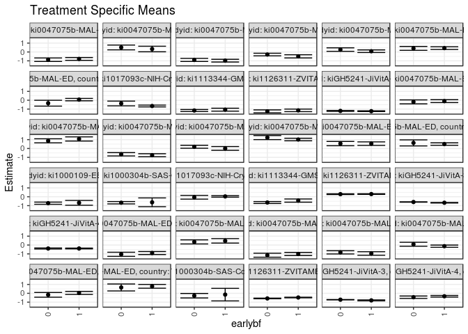

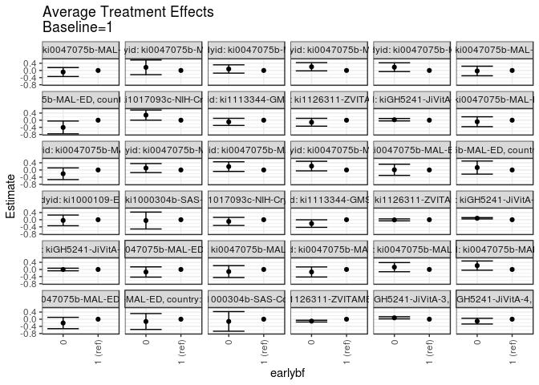

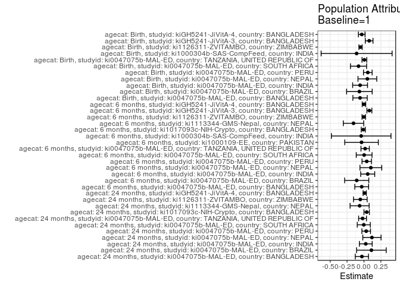

## Results Table

### Parameter: TSM

| agecat | studyid | country | intervention_level | baseline_level | estimate | ci_lower | ci_upper |
| --- | --- | --- | --- | --- | --- | --- | --- |
| Birth | ki0047075b-MAL-ED | BANGLADESH | 1 | NA | -0.9029795 | -1.0729108 | -0.7330481 |
| Birth | ki0047075b-MAL-ED | BANGLADESH | 0 | NA | -1.0448405 | -1.2739437 | -0.8157373 |
| Birth | ki0047075b-MAL-ED | BRAZIL | 1 | NA | 0.4714548 | 0.2194250 | 0.7234846 |
| Birth | ki0047075b-MAL-ED | BRAZIL | 0 | NA | 0.3521698 | 0.1211586 | 0.5831809 |
| Birth | ki0047075b-MAL-ED | INDIA | 1 | NA | -1.0081434 | -1.1838930 | -0.8323938 |
| Birth | ki0047075b-MAL-ED | INDIA | 0 | NA | -1.1500030 | -1.3741544 | -0.9258516 |
| Birth | ki0047075b-MAL-ED | NEPAL | 1 | NA | -0.9548663 | -1.1534019 | -0.7563307 |
| Birth | ki0047075b-MAL-ED | NEPAL | 0 | NA | -0.8257505 | -1.0069443 | -0.6445566 |
| Birth | ki0047075b-MAL-ED | PERU | 1 | NA | -0.1302871 | -0.2555320 | -0.0050422 |
| Birth | ki0047075b-MAL-ED | PERU | 0 | NA | 0.0851588 | -0.1405169 | 0.3108344 |
| Birth | ki0047075b-MAL-ED | SOUTH AFRICA | 1 | NA | 0.0387786 | -0.1331174 | 0.2106745 |
| Birth | ki0047075b-MAL-ED | SOUTH AFRICA | 0 | NA | -0.1743878 | -0.4405802 | 0.0918047 |
| Birth | ki0047075b-MAL-ED | TANZANIA, UNITED REPUBLIC OF | 1 | NA | 0.7869048 | 0.5735121 | 1.0002975 |
| Birth | ki0047075b-MAL-ED | TANZANIA, UNITED REPUBLIC OF | 0 | NA | 0.6580474 | 0.2676074 | 1.0484875 |
| Birth | ki1000304b-SAS-CompFeed | INDIA | 1 | NA | -0.1491040 | -0.8585823 | 0.5603743 |
| Birth | ki1000304b-SAS-CompFeed | INDIA | 0 | NA | -0.2731085 | -0.5268821 | -0.0193348 |
| Birth | ki1126311-ZVITAMBO | ZIMBABWE | 1 | NA | -0.4753152 | -0.5112940 | -0.4393363 |
| Birth | ki1126311-ZVITAMBO | ZIMBABWE | 0 | NA | -0.5822888 | -0.6202532 | -0.5443245 |
| Birth | kiGH5241-JiVitA-3 | BANGLADESH | 1 | NA | -0.8011006 | -0.8552137 | -0.7469875 |
| Birth | kiGH5241-JiVitA-3 | BANGLADESH | 0 | NA | -0.7236316 | -0.7439867 | -0.7032764 |
| Birth | kiGH5241-JiVitA-4 | BANGLADESH | 1 | NA | -0.3354139 | -0.4304976 | -0.2403302 |
| Birth | kiGH5241-JiVitA-4 | BANGLADESH | 0 | NA | -0.4444732 | -0.5813254 | -0.3076211 |
| 6 months | ki0047075b-MAL-ED | BANGLADESH | 1 | NA | -0.1003588 | -0.2629380 | 0.0622203 |
| 6 months | ki0047075b-MAL-ED | BANGLADESH | 0 | NA | -0.1856907 | -0.4095539 | 0.0381725 |
| 6 months | ki0047075b-MAL-ED | BRAZIL | 1 | NA | 1.0788548 | 0.8441725 | 1.3135371 |
| 6 months | ki0047075b-MAL-ED | BRAZIL | 0 | NA | 0.8669524 | 0.6378343 | 1.0960705 |
| 6 months | ki0047075b-MAL-ED | INDIA | 1 | NA | -0.7588412 | -0.9267652 | -0.5909172 |
| 6 months | ki0047075b-MAL-ED | INDIA | 0 | NA | -0.6529678 | -0.8404996 | -0.4654360 |
| 6 months | ki0047075b-MAL-ED | NEPAL | 1 | NA | 0.0088896 | -0.2040357 | 0.2218150 |
| 6 months | ki0047075b-MAL-ED | NEPAL | 0 | NA | 0.1961254 | 0.0294040 | 0.3628468 |
| 6 months | ki0047075b-MAL-ED | PERU | 1 | NA | 1.0133447 | 0.8696180 | 1.1570713 |
| 6 months | ki0047075b-MAL-ED | PERU | 0 | NA | 1.2301331 | 1.0031883 | 1.4570778 |
| 6 months | ki0047075b-MAL-ED | SOUTH AFRICA | 1 | NA | 0.5471562 | 0.3481909 | 0.7461216 |
| 6 months | ki0047075b-MAL-ED | SOUTH AFRICA | 0 | NA | 0.5555599 | 0.3153379 | 0.7957820 |
| 6 months | ki0047075b-MAL-ED | TANZANIA, UNITED REPUBLIC OF | 1 | NA | 0.4992142 | 0.3590441 | 0.6393843 |
| 6 months | ki0047075b-MAL-ED | TANZANIA, UNITED REPUBLIC OF | 0 | NA | 0.6319528 | 0.2919128 | 0.9719928 |
| 6 months | ki1000109-EE | PAKISTAN | 1 | NA | -0.6854849 | -0.9568461 | -0.4141238 |
| 6 months | ki1000109-EE | PAKISTAN | 0 | NA | -0.7244299 | -0.8487372 | -0.6001226 |
| 6 months | ki1000304b-SAS-CompFeed | INDIA | 1 | NA | -0.6246627 | -1.1188936 | -0.1304317 |
| 6 months | ki1000304b-SAS-CompFeed | INDIA | 0 | NA | -0.6709692 | -0.8041478 | -0.5377907 |
| 6 months | ki1017093c-NIH-Crypto | BANGLADESH | 1 | NA | 0.0401264 | -0.0453476 | 0.1256004 |
| 6 months | ki1017093c-NIH-Crypto | BANGLADESH | 0 | NA | -0.0559823 | -0.2651741 | 0.1532094 |
| 6 months | ki1113344-GMS-Nepal | NEPAL | 1 | NA | -0.4305224 | -0.6094963 | -0.2515486 |
| 6 months | ki1113344-GMS-Nepal | NEPAL | 0 | NA | -0.6470287 | -0.7559926 | -0.5380649 |
| 6 months | ki1126311-ZVITAMBO | ZIMBABWE | 1 | NA | 0.3048780 | 0.2675826 | 0.3421734 |
| 6 months | ki1126311-ZVITAMBO | ZIMBABWE | 0 | NA | 0.2945364 | 0.2527412 | 0.3363316 |
| 6 months | kiGH5241-JiVitA-3 | BANGLADESH | 1 | NA | -0.6736161 | -0.7051261 | -0.6421062 |
| 6 months | kiGH5241-JiVitA-3 | BANGLADESH | 0 | NA | -0.5933266 | -0.6133639 | -0.5732894 |
| 6 months | kiGH5241-JiVitA-4 | BANGLADESH | 1 | NA | -0.3900626 | -0.4348072 | -0.3453181 |
| 6 months | kiGH5241-JiVitA-4 | BANGLADESH | 0 | NA | -0.3931291 | -0.4545038 | -0.3317544 |
| 24 months | ki0047075b-MAL-ED | BANGLADESH | 1 | NA | -0.7849255 | -0.9430512 | -0.6267998 |
| 24 months | ki0047075b-MAL-ED | BANGLADESH | 0 | NA | -0.8726824 | -1.0680724 | -0.6772923 |
| 24 months | ki0047075b-MAL-ED | BRAZIL | 1 | NA | 0.3364384 | 0.0232596 | 0.6496172 |
| 24 months | ki0047075b-MAL-ED | BRAZIL | 0 | NA | 0.5104279 | 0.2411780 | 0.7796777 |
| 24 months | ki0047075b-MAL-ED | INDIA | 1 | NA | -0.9793848 | -1.1342275 | -0.8245421 |
| 24 months | ki0047075b-MAL-ED | INDIA | 0 | NA | -0.8970689 | -1.0701012 | -0.7240365 |
| 24 months | ki0047075b-MAL-ED | NEPAL | 1 | NA | -0.4941925 | -0.6727968 | -0.3155883 |
| 24 months | ki0047075b-MAL-ED | NEPAL | 0 | NA | -0.2877345 | -0.4334050 | -0.1420641 |
| 24 months | ki0047075b-MAL-ED | PERU | 1 | NA | 0.0867635 | -0.0591912 | 0.2327182 |
| 24 months | ki0047075b-MAL-ED | PERU | 0 | NA | 0.2695277 | 0.0715829 | 0.4674726 |
| 24 months | ki0047075b-MAL-ED | SOUTH AFRICA | 1 | NA | 0.4359123 | 0.2807159 | 0.5911087 |
| 24 months | ki0047075b-MAL-ED | SOUTH AFRICA | 0 | NA | 0.4060964 | 0.1880303 | 0.6241625 |
| 24 months | ki0047075b-MAL-ED | TANZANIA, UNITED REPUBLIC OF | 1 | NA | 0.0709511 | -0.0644151 | 0.2063172 |
| 24 months | ki0047075b-MAL-ED | TANZANIA, UNITED REPUBLIC OF | 0 | NA | -0.3338241 | -0.6651606 | -0.0024876 |
| 24 months | ki1017093c-NIH-Crypto | BANGLADESH | 1 | NA | -0.6505223 | -0.7511985 | -0.5498462 |
| 24 months | ki1017093c-NIH-Crypto | BANGLADESH | 0 | NA | -0.3652176 | -0.6324288 | -0.0980065 |
| 24 months | ki1113344-GMS-Nepal | NEPAL | 1 | NA | -1.0656831 | -1.2301058 | -0.9012605 |
| 24 months | ki1113344-GMS-Nepal | NEPAL | 0 | NA | -1.1590004 | -1.2708592 | -1.0471415 |
| 24 months | ki1126311-ZVITAMBO | ZIMBABWE | 1 | NA | -1.1425493 | -1.2869284 | -0.9981702 |
| 24 months | ki1126311-ZVITAMBO | ZIMBABWE | 0 | NA | -1.2574246 | -1.4246132 | -1.0902360 |
| 24 months | kiGH5241-JiVitA-4 | BANGLADESH | 1 | NA | -1.2341177 | -1.2742701 | -1.1939653 |
| 24 months | kiGH5241-JiVitA-4 | BANGLADESH | 0 | NA | -1.2064999 | -1.2604495 | -1.1525502 |

### Parameter: E(Y)

| agecat | studyid | country | intervention_level | baseline_level | estimate | ci_lower | ci_upper |
| --- | --- | --- | --- | --- | --- | --- | --- |
| Birth | ki0047075b-MAL-ED | BANGLADESH | NA | NA | -0.9606667 | -1.0969945 | -0.8243389 |
| Birth | ki0047075b-MAL-ED | BRAZIL | NA | NA | 0.4038798 | 0.2296279 | 0.5781316 |
| Birth | ki0047075b-MAL-ED | INDIA | NA | NA | -1.0653960 | -1.2046419 | -0.9261502 |
| Birth | ki0047075b-MAL-ED | NEPAL | NA | NA | -0.9044643 | -1.0439568 | -0.7649718 |
| Birth | ki0047075b-MAL-ED | PERU | NA | NA | -0.0735842 | -0.1836203 | 0.0364518 |
| Birth | ki0047075b-MAL-ED | SOUTH AFRICA | NA | NA | -0.0415102 | -0.1884529 | 0.1054324 |
| Birth | ki0047075b-MAL-ED | TANZANIA, UNITED REPUBLIC OF | NA | NA | 0.7932203 | 0.5962220 | 0.9902187 |
| Birth | ki1000304b-SAS-CompFeed | INDIA | NA | NA | -0.2577848 | -0.5195618 | 0.0039922 |
| Birth | ki1126311-ZVITAMBO | ZIMBABWE | NA | NA | -0.5258212 | -0.5533316 | -0.4983109 |
| Birth | kiGH5241-JiVitA-3 | BANGLADESH | NA | NA | -0.7240919 | -0.7439633 | -0.7042204 |
| Birth | kiGH5241-JiVitA-4 | BANGLADESH | NA | NA | -0.3683163 | -0.4490504 | -0.2875821 |
| 6 months | ki0047075b-MAL-ED | BANGLADESH | NA | NA | -0.1337535 | -0.2628178 | -0.0046891 |
| 6 months | ki0047075b-MAL-ED | BRAZIL | NA | NA | 0.9717225 | 0.8073791 | 1.1360658 |
| 6 months | ki0047075b-MAL-ED | INDIA | NA | NA | -0.7033969 | -0.8285284 | -0.5782654 |
| 6 months | ki0047075b-MAL-ED | NEPAL | NA | NA | 0.1110452 | -0.0202712 | 0.2423616 |
| 6 months | ki0047075b-MAL-ED | PERU | NA | NA | 1.0543956 | 0.9326967 | 1.1760945 |
| 6 months | ki0047075b-MAL-ED | SOUTH AFRICA | NA | NA | 0.5499200 | 0.3963965 | 0.7034435 |
| 6 months | ki0047075b-MAL-ED | TANZANIA, UNITED REPUBLIC OF | NA | NA | 0.5170513 | 0.3872178 | 0.6468847 |
| 6 months | ki1000109-EE | PAKISTAN | NA | NA | -0.7212766 | -0.8346857 | -0.6078675 |
| 6 months | ki1000304b-SAS-CompFeed | INDIA | NA | NA | -0.6657084 | -0.8024377 | -0.5289791 |
| 6 months | ki1017093c-NIH-Crypto | BANGLADESH | NA | NA | 0.0297622 | -0.0491685 | 0.1086930 |
| 6 months | ki1113344-GMS-Nepal | NEPAL | NA | NA | -0.5853922 | -0.6772967 | -0.4934876 |
| 6 months | ki1126311-ZVITAMBO | ZIMBABWE | NA | NA | 0.3021399 | 0.2744461 | 0.3298338 |
| 6 months | kiGH5241-JiVitA-3 | BANGLADESH | NA | NA | -0.5935161 | -0.6130518 | -0.5739805 |
| 6 months | kiGH5241-JiVitA-4 | BANGLADESH | NA | NA | -0.3898055 | -0.4270507 | -0.3525603 |
| 24 months | ki0047075b-MAL-ED | BANGLADESH | NA | NA | -0.8157109 | -0.9379759 | -0.6934459 |
| 24 months | ki0047075b-MAL-ED | BRAZIL | NA | NA | 0.4466272 | 0.2416144 | 0.6516401 |
| 24 months | ki0047075b-MAL-ED | INDIA | NA | NA | -0.9522907 | -1.0676596 | -0.8369219 |
| 24 months | ki0047075b-MAL-ED | NEPAL | NA | NA | -0.3764474 | -0.4898516 | -0.2630431 |
| 24 months | ki0047075b-MAL-ED | PERU | NA | NA | 0.1199005 | -0.0000331 | 0.2398341 |
| 24 months | ki0047075b-MAL-ED | SOUTH AFRICA | NA | NA | 0.4331915 | 0.3126798 | 0.5537032 |
| 24 months | ki0047075b-MAL-ED | TANZANIA, UNITED REPUBLIC OF | NA | NA | 0.0500935 | -0.0748234 | 0.1750103 |
| 24 months | ki1017093c-NIH-Crypto | BANGLADESH | NA | NA | -0.6103502 | -0.7050157 | -0.5156847 |
| 24 months | ki1113344-GMS-Nepal | NEPAL | NA | NA | -1.1298678 | -1.2212513 | -1.0384844 |
| 24 months | ki1126311-ZVITAMBO | ZIMBABWE | NA | NA | -1.1963784 | -1.3049250 | -1.0878318 |
| 24 months | kiGH5241-JiVitA-4 | BANGLADESH | NA | NA | -1.2231088 | -1.2549632 | -1.1912543 |

### Parameter: ATE

| agecat | studyid | country | intervention_level | baseline_level | estimate | ci_lower | ci_upper |
| --- | --- | --- | --- | --- | --- | --- | --- |
| Birth | ki0047075b-MAL-ED | BANGLADESH | 1 | 1 | 0.0000000 | 0.0000000 | 0.0000000 |
| Birth | ki0047075b-MAL-ED | BANGLADESH | 0 | 1 | -0.1418610 | -0.4281306 | 0.1444086 |
| Birth | ki0047075b-MAL-ED | BRAZIL | 1 | 1 | 0.0000000 | 0.0000000 | 0.0000000 |
| Birth | ki0047075b-MAL-ED | BRAZIL | 0 | 1 | -0.1192851 | -0.4514181 | 0.2128480 |
| Birth | ki0047075b-MAL-ED | INDIA | 1 | 1 | 0.0000000 | 0.0000000 | 0.0000000 |
| Birth | ki0047075b-MAL-ED | INDIA | 0 | 1 | -0.1418596 | -0.4234825 | 0.1397632 |
| Birth | ki0047075b-MAL-ED | NEPAL | 1 | 1 | 0.0000000 | 0.0000000 | 0.0000000 |
| Birth | ki0047075b-MAL-ED | NEPAL | 0 | 1 | 0.1291158 | -0.1267295 | 0.3849611 |
| Birth | ki0047075b-MAL-ED | PERU | 1 | 1 | 0.0000000 | 0.0000000 | 0.0000000 |
| Birth | ki0047075b-MAL-ED | PERU | 0 | 1 | 0.2154459 | -0.0429070 | 0.4737987 |
| Birth | ki0047075b-MAL-ED | SOUTH AFRICA | 1 | 1 | 0.0000000 | 0.0000000 | 0.0000000 |
| Birth | ki0047075b-MAL-ED | SOUTH AFRICA | 0 | 1 | -0.2131663 | -0.5308332 | 0.1045005 |
| Birth | ki0047075b-MAL-ED | TANZANIA, UNITED REPUBLIC OF | 1 | 1 | 0.0000000 | 0.0000000 | 0.0000000 |
| Birth | ki0047075b-MAL-ED | TANZANIA, UNITED REPUBLIC OF | 0 | 1 | -0.1288573 | -0.5742676 | 0.3165529 |
| Birth | ki1000304b-SAS-CompFeed | INDIA | 1 | 1 | 0.0000000 | 0.0000000 | 0.0000000 |
| Birth | ki1000304b-SAS-CompFeed | INDIA | 0 | 1 | -0.1240045 | -0.6739494 | 0.4259405 |
| Birth | ki1126311-ZVITAMBO | ZIMBABWE | 1 | 1 | 0.0000000 | 0.0000000 | 0.0000000 |
| Birth | ki1126311-ZVITAMBO | ZIMBABWE | 0 | 1 | -0.1069736 | -0.1553079 | -0.0586394 |
| Birth | kiGH5241-JiVitA-3 | BANGLADESH | 1 | 1 | 0.0000000 | 0.0000000 | 0.0000000 |
| Birth | kiGH5241-JiVitA-3 | BANGLADESH | 0 | 1 | 0.0774690 | 0.0193148 | 0.1356233 |
| Birth | kiGH5241-JiVitA-4 | BANGLADESH | 1 | 1 | 0.0000000 | 0.0000000 | 0.0000000 |
| Birth | kiGH5241-JiVitA-4 | BANGLADESH | 0 | 1 | -0.1090593 | -0.2691778 | 0.0510591 |
| 6 months | ki0047075b-MAL-ED | BANGLADESH | 1 | 1 | 0.0000000 | 0.0000000 | 0.0000000 |
| 6 months | ki0047075b-MAL-ED | BANGLADESH | 0 | 1 | -0.0853319 | -0.3623577 | 0.1916940 |
| 6 months | ki0047075b-MAL-ED | BRAZIL | 1 | 1 | 0.0000000 | 0.0000000 | 0.0000000 |
| 6 months | ki0047075b-MAL-ED | BRAZIL | 0 | 1 | -0.2119024 | -0.5384015 | 0.1145967 |
| 6 months | ki0047075b-MAL-ED | INDIA | 1 | 1 | 0.0000000 | 0.0000000 | 0.0000000 |
| 6 months | ki0047075b-MAL-ED | INDIA | 0 | 1 | 0.1058734 | -0.1468098 | 0.3585566 |
| 6 months | ki0047075b-MAL-ED | NEPAL | 1 | 1 | 0.0000000 | 0.0000000 | 0.0000000 |
| 6 months | ki0047075b-MAL-ED | NEPAL | 0 | 1 | 0.1872358 | -0.0826669 | 0.4571384 |
| 6 months | ki0047075b-MAL-ED | PERU | 1 | 1 | 0.0000000 | 0.0000000 | 0.0000000 |
| 6 months | ki0047075b-MAL-ED | PERU | 0 | 1 | 0.2167884 | -0.0517920 | 0.4853688 |
| 6 months | ki0047075b-MAL-ED | SOUTH AFRICA | 1 | 1 | 0.0000000 | 0.0000000 | 0.0000000 |
| 6 months | ki0047075b-MAL-ED | SOUTH AFRICA | 0 | 1 | 0.0084037 | -0.3040468 | 0.3208542 |
| 6 months | ki0047075b-MAL-ED | TANZANIA, UNITED REPUBLIC OF | 1 | 1 | 0.0000000 | 0.0000000 | 0.0000000 |
| 6 months | ki0047075b-MAL-ED | TANZANIA, UNITED REPUBLIC OF | 0 | 1 | 0.1327386 | -0.2343190 | 0.4997961 |
| 6 months | ki1000109-EE | PAKISTAN | 1 | 1 | 0.0000000 | 0.0000000 | 0.0000000 |
| 6 months | ki1000109-EE | PAKISTAN | 0 | 1 | -0.0389450 | -0.3377701 | 0.2598801 |
| 6 months | ki1000304b-SAS-CompFeed | INDIA | 1 | 1 | 0.0000000 | 0.0000000 | 0.0000000 |
| 6 months | ki1000304b-SAS-CompFeed | INDIA | 0 | 1 | -0.0463066 | -0.5191029 | 0.4264897 |
| 6 months | ki1017093c-NIH-Crypto | BANGLADESH | 1 | 1 | 0.0000000 | 0.0000000 | 0.0000000 |
| 6 months | ki1017093c-NIH-Crypto | BANGLADESH | 0 | 1 | -0.0961087 | -0.3219426 | 0.1297251 |
| 6 months | ki1113344-GMS-Nepal | NEPAL | 1 | 1 | 0.0000000 | 0.0000000 | 0.0000000 |
| 6 months | ki1113344-GMS-Nepal | NEPAL | 0 | 1 | -0.2165063 | -0.4276300 | -0.0053826 |
| 6 months | ki1126311-ZVITAMBO | ZIMBABWE | 1 | 1 | 0.0000000 | 0.0000000 | 0.0000000 |
| 6 months | ki1126311-ZVITAMBO | ZIMBABWE | 0 | 1 | -0.0103416 | -0.0660379 | 0.0453548 |
| 6 months | kiGH5241-JiVitA-3 | BANGLADESH | 1 | 1 | 0.0000000 | 0.0000000 | 0.0000000 |
| 6 months | kiGH5241-JiVitA-3 | BANGLADESH | 0 | 1 | 0.0802895 | 0.0427335 | 0.1178455 |
| 6 months | kiGH5241-JiVitA-4 | BANGLADESH | 1 | 1 | 0.0000000 | 0.0000000 | 0.0000000 |
| 6 months | kiGH5241-JiVitA-4 | BANGLADESH | 0 | 1 | -0.0030664 | -0.0759350 | 0.0698021 |
| 24 months | ki0047075b-MAL-ED | BANGLADESH | 1 | 1 | 0.0000000 | 0.0000000 | 0.0000000 |
| 24 months | ki0047075b-MAL-ED | BANGLADESH | 0 | 1 | -0.0877569 | -0.3385232 | 0.1630095 |
| 24 months | ki0047075b-MAL-ED | BRAZIL | 1 | 1 | 0.0000000 | 0.0000000 | 0.0000000 |
| 24 months | ki0047075b-MAL-ED | BRAZIL | 0 | 1 | 0.1739895 | -0.2365008 | 0.5844798 |
| 24 months | ki0047075b-MAL-ED | INDIA | 1 | 1 | 0.0000000 | 0.0000000 | 0.0000000 |
| 24 months | ki0047075b-MAL-ED | INDIA | 0 | 1 | 0.0823159 | -0.1491764 | 0.3138082 |
| 24 months | ki0047075b-MAL-ED | NEPAL | 1 | 1 | 0.0000000 | 0.0000000 | 0.0000000 |
| 24 months | ki0047075b-MAL-ED | NEPAL | 0 | 1 | 0.2064580 | -0.0240543 | 0.4369703 |
| 24 months | ki0047075b-MAL-ED | PERU | 1 | 1 | 0.0000000 | 0.0000000 | 0.0000000 |
| 24 months | ki0047075b-MAL-ED | PERU | 0 | 1 | 0.1827642 | -0.0631620 | 0.4286904 |
| 24 months | ki0047075b-MAL-ED | SOUTH AFRICA | 1 | 1 | 0.0000000 | 0.0000000 | 0.0000000 |
| 24 months | ki0047075b-MAL-ED | SOUTH AFRICA | 0 | 1 | -0.0298159 | -0.2977012 | 0.2380693 |
| 24 months | ki0047075b-MAL-ED | TANZANIA, UNITED REPUBLIC OF | 1 | 1 | 0.0000000 | 0.0000000 | 0.0000000 |
| 24 months | ki0047075b-MAL-ED | TANZANIA, UNITED REPUBLIC OF | 0 | 1 | -0.4047751 | -0.7626860 | -0.0468642 |
| 24 months | ki1017093c-NIH-Crypto | BANGLADESH | 1 | 1 | 0.0000000 | 0.0000000 | 0.0000000 |
| 24 months | ki1017093c-NIH-Crypto | BANGLADESH | 0 | 1 | 0.2853047 | 0.0002762 | 0.5703332 |
| 24 months | ki1113344-GMS-Nepal | NEPAL | 1 | 1 | 0.0000000 | 0.0000000 | 0.0000000 |
| 24 months | ki1113344-GMS-Nepal | NEPAL | 0 | 1 | -0.0933172 | -0.2923626 | 0.1057281 |
| 24 months | ki1126311-ZVITAMBO | ZIMBABWE | 1 | 1 | 0.0000000 | 0.0000000 | 0.0000000 |
| 24 months | ki1126311-ZVITAMBO | ZIMBABWE | 0 | 1 | -0.1148753 | -0.3338298 | 0.1040791 |
| 24 months | kiGH5241-JiVitA-4 | BANGLADESH | 1 | 1 | 0.0000000 | 0.0000000 | 0.0000000 |
| 24 months | kiGH5241-JiVitA-4 | BANGLADESH | 0 | 1 | 0.0276178 | -0.0398934 | 0.0951291 |

### Parameter: PAR

| agecat | studyid | country | intervention_level | baseline_level | estimate | ci_lower | ci_upper |
| --- | --- | --- | --- | --- | --- | --- | --- |
| Birth | ki0047075b-MAL-ED | BANGLADESH | 1 | NA | -0.0576872 | -0.1639702 | 0.0485958 |
| Birth | ki0047075b-MAL-ED | BRAZIL | 1 | NA | -0.0675750 | -0.2570065 | 0.1218564 |
| Birth | ki0047075b-MAL-ED | INDIA | 1 | NA | -0.0572527 | -0.1671716 | 0.0526663 |
| Birth | ki0047075b-MAL-ED | NEPAL | 1 | NA | 0.0504020 | -0.0884119 | 0.1892159 |
| Birth | ki0047075b-MAL-ED | PERU | 1 | NA | 0.0567029 | -0.0072947 | 0.1207004 |
| Birth | ki0047075b-MAL-ED | SOUTH AFRICA | 1 | NA | -0.0802888 | -0.1998909 | 0.0393134 |
| Birth | ki0047075b-MAL-ED | TANZANIA, UNITED REPUBLIC OF | 1 | NA | 0.0063156 | -0.0288100 | 0.0414411 |
| Birth | ki1000304b-SAS-CompFeed | INDIA | 1 | NA | -0.1086808 | -0.6338694 | 0.4165078 |
| Birth | ki1126311-ZVITAMBO | ZIMBABWE | 1 | NA | -0.0505061 | -0.0746851 | -0.0263270 |
| Birth | kiGH5241-JiVitA-3 | BANGLADESH | 1 | NA | 0.0770087 | 0.0203078 | 0.1337096 |
| Birth | kiGH5241-JiVitA-4 | BANGLADESH | 1 | NA | -0.0329023 | -0.0823101 | 0.0165054 |
| 6 months | ki0047075b-MAL-ED | BANGLADESH | 1 | NA | -0.0333946 | -0.1357939 | 0.0690046 |
| 6 months | ki0047075b-MAL-ED | BRAZIL | 1 | NA | -0.1071323 | -0.2856973 | 0.0714327 |
| 6 months | ki0047075b-MAL-ED | INDIA | 1 | NA | 0.0554443 | -0.0483291 | 0.1592177 |
| 6 months | ki0047075b-MAL-ED | NEPAL | 1 | NA | 0.1021556 | -0.0592264 | 0.2635376 |
| 6 months | ki0047075b-MAL-ED | PERU | 1 | NA | 0.0410510 | -0.0287363 | 0.1108382 |
| 6 months | ki0047075b-MAL-ED | SOUTH AFRICA | 1 | NA | 0.0027638 | -0.1139228 | 0.1194503 |
| 6 months | ki0047075b-MAL-ED | TANZANIA, UNITED REPUBLIC OF | 1 | NA | 0.0178370 | -0.0441223 | 0.0797964 |
| 6 months | ki1000109-EE | PAKISTAN | 1 | NA | -0.0357917 | -0.2842486 | 0.2126653 |
| 6 months | ki1000304b-SAS-CompFeed | INDIA | 1 | NA | -0.0410457 | -0.4823575 | 0.4002660 |
| 6 months | ki1017093c-NIH-Crypto | BANGLADESH | 1 | NA | -0.0103642 | -0.0403979 | 0.0196696 |
| 6 months | ki1113344-GMS-Nepal | NEPAL | 1 | NA | -0.1548697 | -0.3055945 | -0.0041449 |
| 6 months | ki1126311-ZVITAMBO | ZIMBABWE | 1 | NA | -0.0027381 | -0.0286102 | 0.0231341 |
| 6 months | kiGH5241-JiVitA-3 | BANGLADESH | 1 | NA | 0.0801000 | 0.0434691 | 0.1167309 |
| 6 months | kiGH5241-JiVitA-4 | BANGLADESH | 1 | NA | 0.0002571 | -0.0258199 | 0.0263342 |
| 24 months | ki0047075b-MAL-ED | BANGLADESH | 1 | NA | -0.0307854 | -0.1287047 | 0.0671339 |
| 24 months | ki0047075b-MAL-ED | BRAZIL | 1 | NA | 0.1101888 | -0.1090118 | 0.3293895 |
| 24 months | ki0047075b-MAL-ED | INDIA | 1 | NA | 0.0270941 | -0.0676418 | 0.1218299 |
| 24 months | ki0047075b-MAL-ED | NEPAL | 1 | NA | 0.1177452 | -0.0176124 | 0.2531028 |
| 24 months | ki0047075b-MAL-ED | PERU | 1 | NA | 0.0331370 | -0.0306316 | 0.0969057 |
| 24 months | ki0047075b-MAL-ED | SOUTH AFRICA | 1 | NA | -0.0027208 | -0.0992742 | 0.0938326 |
| 24 months | ki0047075b-MAL-ED | TANZANIA, UNITED REPUBLIC OF | 1 | NA | -0.0208576 | -0.0789376 | 0.0372224 |
| 24 months | ki1017093c-NIH-Crypto | BANGLADESH | 1 | NA | 0.0401721 | 0.0002006 | 0.0801437 |
| 24 months | ki1113344-GMS-Nepal | NEPAL | 1 | NA | -0.0641847 | -0.2052615 | 0.0768921 |
| 24 months | ki1126311-ZVITAMBO | ZIMBABWE | 1 | NA | -0.0538291 | -0.1545640 | 0.0469059 |
| 24 months | kiGH5241-JiVitA-4 | BANGLADESH | 1 | NA | 0.0110089 | -0.0132216 | 0.0352395 |